# Projeto de Capacidade Produtiva- Fase II

Allan B. Martins

24 maio 2022

# 1 ACP **2021** - **JAN A DEZ** - **Variáveis estruturantes** - (**v5**)

# Técnica utilizada para PCA análise de componentes principais acp ou pca -

Contextualização

A Metodologia ANÁLISE DE COMPONENTES PRINCIPAIS

A Análise de Componentes Principais ou PCA (Principal Component Analysis) é uma técnica de análise multivariada que pode ser usada para analisar inter-relações entre um grande número de variáveis e explicar essas variáveis em termos de suas dimensões inerentes (Componentes).

O objetivo é encontrar um meio de condensar a informação contida em várias variáveis originais em um conjunto menor de variáveis estatísticas (componentes) com uma perda mínima de informação.

O número de componentes principais se torna o número de variáveis consideradas na análise, mas geralmente as primeiras componentes são as mais importantes já que explicam a maior parte da variação total.

As componentes principais em geral são extraídas via matriz de covariância, mas também podem ser extraídas via matriz de correlação. baseia-se numa formulação matemática sofisticada.

Usaremos a função “factoextra” e “FactoMineR” desse pacote factoextra é um pacote R que facilita a extração e visualização da saída de análises exploratórias de dados multivariados, incluindo:

Análise de Componentes Principais (PCA), que é usada para resumir as informações contidas em dados multivariados contínuos (ou seja, quantitativos) reduzindo a dimensionalidade dos dados sem perder informações importantes.

## 1.1 Análises por variável estruturante

O banco de dados analisado traz os dados das variáveis estruturantes que são **zs_energ**, **zs_transp**,**zs_telecom**,**zs_snb**,**zs_econ**,**zs_seg_nub_n**,**zs_geo_n**, e **zs_estaber_capta**. Por meio da técnica de ACP para definir pesos entre as variáveis estruturantes criação de variável “INFRA” para a etapa II do projeto capacidade produtiva.

### 1.1.1 Etapa I - Estruturação do banco de dados

Tabela de dados variáveis estruturantes

| zs_energ | zs_transp | zs_telecom | zs_snb | zs_econ | zs_seg_nub_n | zs_geo_n | zs_estaber_capta |
| --- | --- | --- | --- | --- | --- | --- | --- |
| 0.00 | 15.5 | 18.2 | 9.0 | 0.0 | 99 | 0 | 12.6 |
| 56.80 | 73.1 | 7.1 | 26.7 | 9.6 | 97 | 100 | 20.5 |
| 0.21 | 0.0 | 6.3 | 4.8 | 76.8 | 96 | 71 | 4.4 |
| 1.98 | 6.5 | 29.5 | 34.2 | 7.3 | 100 | 47 | 8.1 |
| 8.03 | 25.6 | 25.4 | 58.3 | 31.1 | 83 | 100 | 40.6 |
| 10.02 | 35.9 | 16.2 | 61.1 | 18.1 | 88 | 100 | 39.6 |
| 16.18 | 48.6 | 28.8 | 97.3 | 73.6 | 91 | 100 | 83.5 |
| 10.98 | 23.8 | 11.6 | 30.9 | 42.1 | 88 | 100 | 72.1 |
| 3.62 | 21.3 | 20.8 | 0.0 | 11.1 | 93 | 100 | 0.0 |
| 13.12 | 31.4 | 12.6 | 92.5 | 71.8 | 84 | 100 | 72.1 |
| 5.33 | 23.9 | 39.0 | 65.3 | 71.2 | 97 | 48 | 67.7 |
| 1.06 | 9.8 | 29.3 | 22.3 | 54.4 | 96 | 83 | 80.9 |
| 4.64 | 4.0 | 54.5 | 1.2 | 60.9 | 92 | 94 | 7.9 |
| 4.85 | 51.5 | 3.2 | 68.3 | 13.9 | 98 | 100 | 34.3 |
| 17.60 | 53.5 | 6.0 | 78.9 | 27.6 | 84 | 100 | 21.6 |
| 2.02 | 22.9 | 6.5 | 4.5 | 7.8 | 95 | 100 | 37.8 |
| 39.75 | 44.7 | 11.8 | 50.4 | 93.8 | 83 | 67 | 94.2 |
| 100.00 | 100.0 | 70.5 | 94.3 | 98.3 | 62 | 100 | 59.5 |
| 24.81 | 65.3 | 0.0 | 40.7 | 25.8 | 96 | 100 | 34.1 |
| 9.30 | 17.1 | 9.4 | 2.8 | 31.7 | 97 | 44 | 37.8 |
| 0.38 | 10.6 | 6.6 | 29.8 | 5.0 | 100 | 10 | 14.5 |
| 14.18 | 45.7 | 24.8 | 28.1 | 84.0 | 85 | 51 | 87.9 |
| 25.77 | 56.7 | 17.3 | 36.4 | 100.0 | 92 | 77 | 100.0 |
| 72.49 | 32.5 | 48.9 | 41.0 | 26.5 | 98 | 100 | 16.7 |
| 44.47 | 9.8 | 100.0 | 100.0 | 87.5 | 0 | 100 | 78.6 |
| 2.97 | 14.4 | 11.6 | 8.3 | 17.7 | 99 | 100 | 52.3 |

### 1.1.2 Etapa II - Análise de Componentes Principais (PCA)

```
##       eigenvalue variance.percent cumulative.variance.percent
## Dim.1       3.57             44.6                          45
## Dim.2       1.43             17.9                          63
## Dim.3       1.13             14.2                          77
## Dim.4       0.78              9.7                          86
## Dim.5       0.55              6.9                          93
## Dim.6       0.25              3.1                          96
## Dim.7       0.19              2.3                          99
## Dim.8       0.10              1.3                         100
```

#### 1.1.2.1 Gráficos de contribuição das variáveis

##### 1.1.2.1.1 A função fviz_contrib() cria uma parcela de contribuições de linha/coluna. Uma linha tracejada de referência também é mostrada no barplot. Esta linha de referência corresponde ao valor esperado se a contribuição for uniforme.

Para uma determinada dimensão, qualquer linha/coluna com contribuição acima da linha de referência poderia ser considerada como importante para contribuir para a dimensão.

[figure not shown]

##### 1.1.2.1.2 A função fviz_eig() visualiza os valores de eigen (enredo scree). Mostre a porcentagem de variâncias explicadas por cada componente principal.

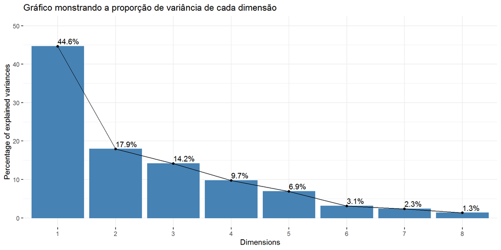

##### 1.1.2.1.3 Gráfico de variáveis. Variáveis correlacionadas positivas apontam para o mesmo lado da trama. Variáveis correlacionadas negativas apontam para lados opostos do gráfico.

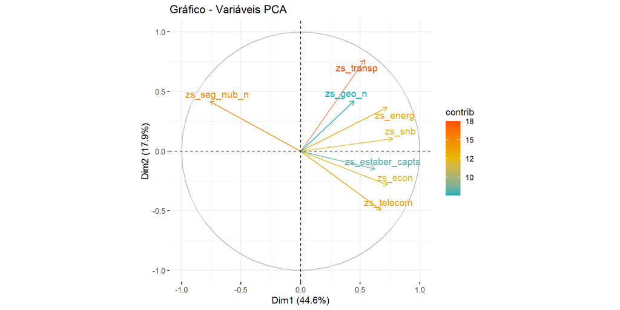

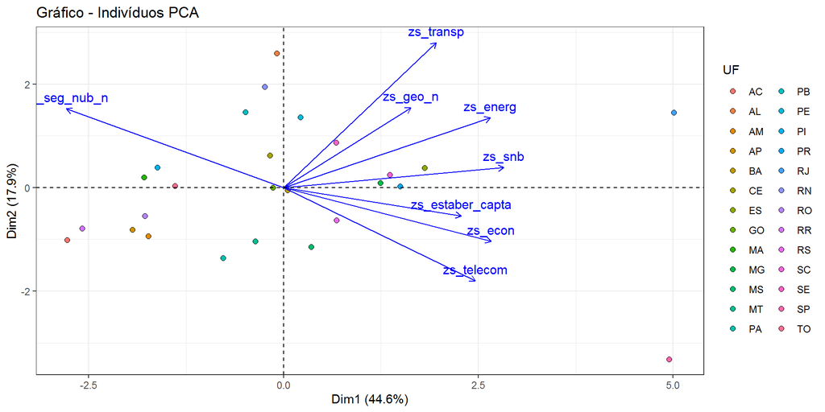

#### 1.1.2.2 Extrair os resultados das variáveis

Resultados por variáveis acumulado por Dim 1-3

|  | Dim1 | Dim2 | Dim3 | SomaDim13 | percentDim13 |
| --- | --- | --- | --- | --- | --- |
| zs_estaber_capta | 10.9 | 1.55 | 42.36 | 55 | 18.27% |
| zs_transp | 8.1 | 41.05 | 1.44 | 51 | 16.85% |
| zs_telecom | 12.7 | 16.99 | 17.62 | 47 | 15.78% |
| zs_econ | 14.9 | 5.62 | 17.28 | 38 | 12.60% |
| zs_seg_nub_n | 16.3 | 12.10 | 7.64 | 36 | 12.00% |
| zs_energ | 14.8 | 9.46 | 7.89 | 32 | 10.71% |
| zs_geo_n | 5.6 | 12.45 | 5.62 | 24 | 7.89% |
| zs_snb | 16.8 | 0.78 | 0.15 | 18 | 5.90% |

# 2 Diversos

## 2.1 Créditos - Participantes do Projeto Capacidade Produtiva:

**MEMBROS DO PROJETO**  
Allan Batista Martins,  
##

## 2.2 Material de Apoio

- Multivariate Data Analyses:[]https://rpkgs.datanovia.com/factoextra/index.html)
- A Metodologia PCA: []https://operdata.com.br/blog/analise-de-componentes-principais/
- PCA análise de componentes principais acp ou pca:[]https://youtu.be/hmp9KIPb5Ig
- PCA dúvidas e sugestões sobre análise de componentes principais:[]https://youtu.be/ATXoqEtNtdg
- PLAYLIST - R na Pesquisa Contábil (Parte 1 ao 20):[]https://youtube.com/playlist?list=PLF3Sjk1EY74ZcUWHE6ZDPHFRu9zp_20gD
- PLAYLIST - Criando gráficos no R com o ggplot2 (Parte 1 ao 2): [Fernanda Peres]https://youtu.be/DYsPRa3vpf0
- PLAYLIST - R Markdown: Gerando relatórios usando o R (Parte 1 ao 5): [Fernanda Peres]https://youtu.be/obxa5VH4WvY
- Minicurso R - UFPR: [UFPR]https://youtu.be/obxa5VH4WvY
- R Markdown: The Definitive Guide: [Yihui Xie, J. J. Allaire, Garrett Grolemund]https://bookdown.org/yihui/rmarkdown/